# Project1

Greg Dimock

03/08/2016

To start exploring energy load data, three datasets will be read in: electric load data, weather data, and billing data. The load and billing data are read from an excel file using the readxl library, with the read_excel function. Initially, only 65536 rows were being read in, likely due to the file being read as a pre-2007 excel workbook. However this was easily fixed by re-saving the electric load file as another excel workbook. The weather data is a text file and is read in with fixed width parsing.

```r
options(width=120)

#load required library to read in excel files
library(readxl)

#write a getloaddf() function to read in the electric load data. Within the function, some clean up #is performed on the informats of the date and time columns. They are then combined to create a #dates column with the paste and strptime functions. Additionally they are converted to POSIX.ct #format. The final format for dates is in month-day-year Hour:Min. The dates range from 1/1/2014 to 12/30/2015.

#Note: The hour is specified for the hour in which the reading took place, not necessarily what hour the meter reading was for. For example, at a 1pm reading, this is associated with the 1pm hour during aggregation, even though it is a result of 12:45pm - 1pm window. This 15 minute shift will not cause a major change in the overall results.

#The ... for the function inputs is used to pass arguments to the read_excel function.
getloaddatadf <- function(filepath,...){
  tempds <- read_excel(filepath,...)
  tempds$WideDate <- ifelse(nchar(tempds$DATE) < 6 ,                                                          paste('0',tempds$DATE,sep=''),tempds$DATE)
  tempds$HOUR <- substr(tempds$TIME,1,nchar(tempds$TIME)-2)
  tempds$HOUR <- ifelse(tempds$HOUR == '','0',tempds$HOUR)
  tempds$MIN <- substr(tempds$TIME,nchar(tempds$TIME)-1,nchar(tempds$TIME))
  tempds$Dates <- as.POSIXct(strptime(paste(tempds$WideDate,tempds$HOUR,tempds$MIN,sep=' '),format = '%m%d%y %H %M')
                            )
  outdsn <- subset(tempds,select = c(Dates,kWh,kVARh))
  return(outdsn)
}

#call the function and return the result to eloaddf
eloaddf <- getloaddatadf(
            filepath= "C:/Users/User/Documents/GitHub/project1/elecloaddata2.xlsx"              ,sheet = 1, col_names = TRUE,col_types = NULL)

#Now lets view what the eloaddf looks like:
head(eloaddf,n = 5)
```

```
##                 Dates    kWh  kVARh
## 1 2014-01-01 00:15:00 81.384 72.912
## 2 2014-01-01 00:30:00 94.608 89.136
## 3 2014-01-01 00:45:00 76.968 69.696
## 4 2014-01-01 01:00:00 90.048 82.968
## 5 2014-01-01 01:15:00 69.384 61.104
```

```r
#Write the function to read in the text file weather data.
getweatherdf <- function(filepath,...){
  indsn <- read.fwf(filepath,...)
  indsn$Dates <- as.POSIXct(strptime(as.character(indsn$DATETIME),format = '%Y%m%d%H%M' ))
  indsn$TEMP <- as.numeric(as.character(indsn$TEMP))
  return(indsn)
}

#Set parameters to read into getweatherdf function. The data specs doc on the fixed width column #positions were used to create the filewidths vector
myweatherfile <- "C:/Users/User/Documents/GitHub/project1/1874606932872dat.txt"
filewidths <- c(7,6,13,4,4,4,4,4,2,2,2,5,3,3,3,3,3,3,3,3,2,5,5,7,6,7,4,4,6,6,6,6,2)
colname_vec <- c('STATION','WBAN_ID','DATETIME','WIND_DIR','WIND_SPD','WIND_GUS','CLOUD_CEIL','SKY_COVER','LOW_CLOUD','MID_CLOUD','HIGH_CLOUD','VISIB','MW1','MW2','MW3','MW4','AW1','AW2','AW3','AW4','PW','TEMP','DEWP','SLP','ALT','STP','MAX_TEMP','MIN_TEMP','PCP01','PCP06','PCP24','PCPXX','SNOW')

#call the getweatherdf function
weatherdf <- getweatherdf(filepath = myweatherfile,widths = filewidths,col.names = colname_vec,skip = 1)
#Removes rows that havea missing temperature data information -- which will become important when we start building models.
weatherdf <- weatherdf[complete.cases(weatherdf["TEMP"]),]


#Let's view the weather data as well:
head(weatherdf, n = 5)
```

```
##   STATION WBAN_ID    DATETIME WIND_DIR WIND_SPD WIND_GUS CLOUD_CEIL SKY_COVER LOW_CLOUD MID_CLOUD HIGH_CLOUD VISIB MW1
## 1  724075   13735 2.01401e+11     300        8      ***        722       CLR         *         *          *  10.0  **
## 2  724075   13735 2.01401e+11     300        9      ***        722       CLR         *         *          *  10.0  **
## 3  724075   13735 2.01401e+11     310        6      ***        722       CLR         *         *          *  10.0  **
## 4  724075   13735 2.01401e+11     ***        0      ***        722       CLR         *         *          *  10.0  **
## 5  724075   13735 2.01401e+11     ***        0      ***        722       CLR         *         *          *  10.0  **
##   MW2 MW3 MW4 AW1 AW2 AW3 AW4 PW TEMP  DEWP     SLP    ALT     STP MAX_TEMP MIN_TEMP  PCP01  PCP06  PCP24  PCPXX SNOW
## 1 **  **  **  **  **  **  **  *    33   16  1024.9  30.27  1022.3      ***      ***   0.00  *****  *****  *****    **
## 2 **  **  **  **  **  **  **  *    31   16  1025.5  30.29  1022.9      ***      ***   0.00  *****  *****  *****    **
## 3 **  **  **  **  **  **  **  *    29   16  1026.1  30.30  1023.3      ***      ***   0.00  *****  *****  *****    **
## 4 **  **  **  **  **  **  **  *    23   18  1026.8  30.32  1024.0      ***      ***   0.00  *****  *****  *****    **
## 5 **  **  **  **  **  **  **  *    23   17  1027.2  30.34  1024.6       41       22   0.00  *****  *****  *****    **
##                 Dates
## 1 2014-01-01 00:54:00
## 2 2014-01-01 01:54:00
## 3 2014-01-01 02:54:00
## 4 2014-01-01 03:54:00
## 5 2014-01-01 04:54:00
```

```r
#similar to the getelecloaddf() function, we use the read_excel function again
getbillsdf <- function(filepath,...){
  indsn <- read_excel(filepath,...)
  return(indsn[1:12,])
}

#set parameters for getbillsdf function
mybilldata <- "C:/Users/User/Documents/GitHub/project1/billdata.xlsx"
col_names_bill<-c('billdate', 'billstartdt', 'billenddt', 'kwh', 'mindemandkw', 'actualdemandkw', 'custcharge','distchrgkw', 'mttkwh', 'tbckwh','nugckwh', 'sbckwh', 'rggieekwh', 'deliverykwh','totdeliverychrg', 'supplychrg', 'totalchrg')

#call getbillsdf function
billsdf <- getbillsdf(filepath = mybilldata,sheet = 1, col_names = col_names_bill,col_types = NULL, skip = 1)

#And lets view the billing information data.
head(billsdf,n = 2)
```

```
##     billdate billstartdt  billenddt   kwh mindemandkw actualdemandkw custcharge distchrgkw    mttkwh    tbckwh  nugckwh
## 1 2015-01-01  2014-12-20 2015-01-28 66460      140.48          130.2     175.15  10.213340 0.0043541 0.0067019 0.012234
## 2 2015-02-01  2015-01-29 2015-02-26 41180      140.48          107.6     126.98   7.404784 0.0043541 0.0067019 0.012234
##     sbckwh rggieekwh deliverykwh totdeliverychrg supplychrg totalchrg
## 1 0.008285 0.0006199   0.0321949        3749.593   6140.904  9890.497
## 2 0.008285 0.0006199   0.0321949        2492.990   3805.032  6298.022
```

Next, lets look at the monthly profile of the electric load data.

```r
# Here, I would like to clean this section up further, sorting the results in the correct, calender - order, and presenting the output in a cleaner fashion.
kWHbyMonth <- data.frame(eloaddf$kWh,format(eloaddf$Dates, '%b-%Y'))
names(kWHbyMonth) <- c('kWh','Month')
agg_unsorted <- aggregate(kWh ~ Month,kWHbyMonth,sum)
#Dividing kWh by 4 as they are reported in 15 minute increments
agg_unsorted$kWh <- agg_unsorted$kWh / 4
agg_unsorted
```

```
##       Month       kWh
## 1  Apr-2014  94308.47
## 2  Apr-2015  90081.47
## 3  Aug-2014 110559.19
## 4  Aug-2015 106865.86
## 5  Dec-2014  85496.95
## 6  Dec-2015  91271.39
## 7  Feb-2014  72540.53
## 8  Feb-2015  69201.11
## 9  Jan-2014  77487.21
## 10 Jan-2015  77497.20
## 11 Jul-2014 109064.87
## 12 Jul-2015 102136.43
## 13 Jun-2014 107376.34
## 14 Jun-2015  98920.16
## 15 Mar-2014  75013.47
## 16 Mar-2015  82809.19
## 17 May-2014 103573.59
## 18 May-2015 100248.01
## 19 Nov-2014  92413.31
## 20 Nov-2015 110820.73
## 21 Oct-2014 119254.46
## 22 Oct-2015 123528.55
## 23 Sep-2014 108881.82
## 24 Sep-2015 101262.10
```

Now let us do some plotting of the load data.

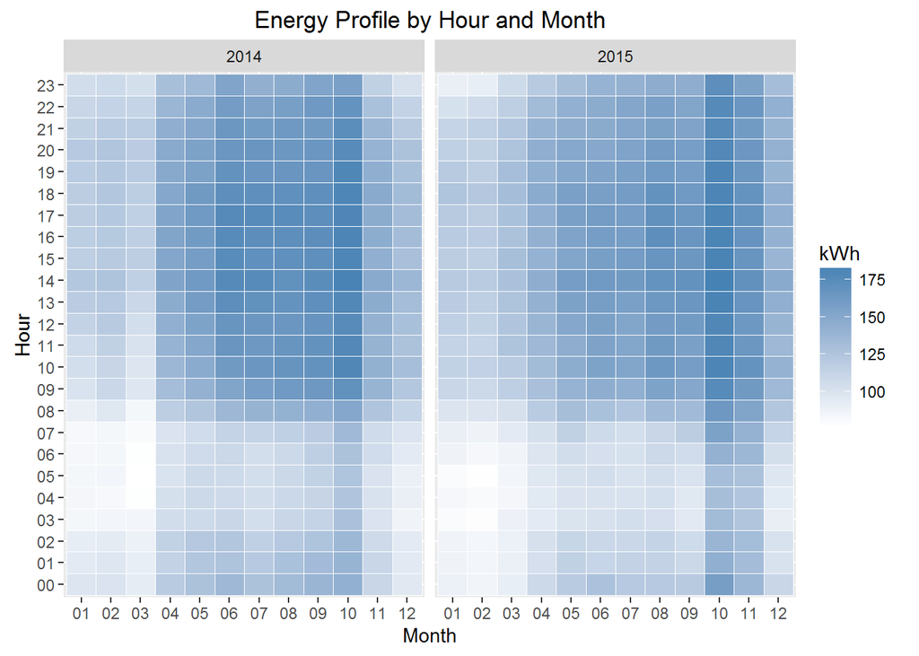

```r
# I have taken advantage of the aggregate and format functions, but this results in returning a character format to the aggregated value. Therefore, I re applied the POSIXct format. I was unable to find a more direct function can that just aggregate and keep date format. Lubridate and xts packages were explored but not implemented. Methods to conditionally loop through the entire dataset were considered but not atempted or tested.

eloadhrdf <- aggregate(kWh ~ format(Dates,'%d%m%Y:%H'),eloaddf,mean)
names(eloadhrdf) <- c('DayHour','kWh')
eloadhrdf$DayHour <- as.POSIXct(strptime(eloadhrdf$DayHour, format = '%d%m%Y:%H'))

#Since the eloadhrdf is summarized only by hour, I will create another dataframe that averages the hourly data per month. This new dataframe will then be the correct format to pass into a ggplot2 heatmap. I wil subset based on year to create side by side comparisons for 2014 and 2015, rather than create two seperate dataframes for each year.

library("ggplot2")
eloadhrdf$Month <- as.factor(format(eloadhrdf$DayHour, "%m"))
eloadhrdf$Hour <- as.factor(format(eloadhrdf$DayHour, "%H"))
eloadhrdf$Year <- as.factor(format(eloadhrdf$DayHour, "%Y"))
loadprofiledf <- aggregate(kWh ~ Year + Month + Hour, data = eloadhrdf, FUN = "mean")

#Create a heatmap and view it.
heatmap1 <- ggplot(data = loadprofiledf, mapping = aes(Month, Hour)) + geom_tile(aes(fill = kWh), colour = "white")+ scale_fill_gradient(low = "white", high = "steelblue") + facet_wrap(~Year) + ggtitle("Energy Profile by Hour and Month")
heatmap1
```

We plot the weather data using boxplot to explore the variation in temperature graphically

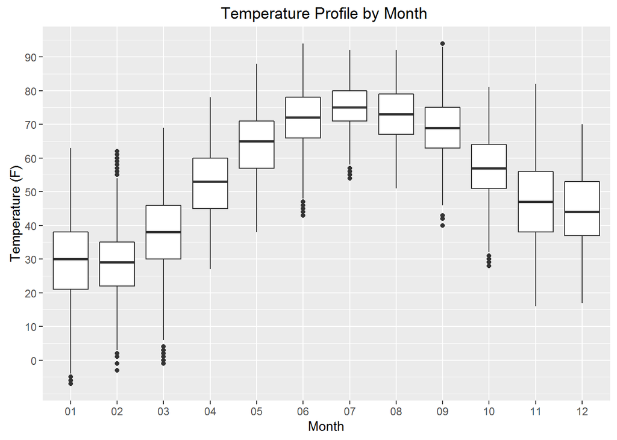

```r
# plot the weather data. Use boxplots in ggplot2 with month on the x-axis and temperature in y-axis
#convert data columns to the appropiate format for months and temps. Some NAs will be introduced from converting the TEMP, which is currently a factor to numeric because of the ** values in the raw data
weatherdf$TEMP <- as.numeric(as.character(weatherdf$TEMP))
weatherdf$Month <- as.factor(format(weatherdf$Dates,'%m'))
#location is Cumberland County; NJ

boxplot <- ggplot(data = na.omit(weatherdf),mapping = aes(x = Month, y = TEMP )) + geom_boxplot() + scale_y_continuous(name = "Temperature (F)" , breaks = seq(0,100,10)) + xlab("Month")+ ggtitle("Temperature Profile by Month ")
boxplot
```

The weather station that the readings were taken at is from Cumberland County NJ, and the box plot shows temperatures that would be expected of this region. Colder in January and February, with a few days falling below 0 a few days in the winter months and the warmer summer months having their hottest temperatures just above 90 F.

The heatmap also shows some intersting trends. As expected the nightly hours between Midnight and 7am use the least amount of energy, and working hours during the day, 8am - 6pm, use the most. One interesting thing to point out is how much less energy is being used in the winter months. (This seems non-intuitive if this was energy data for a business or household, as they would have to heat their buildings, but I do not know what this data is representative of). Furthermore, Month 10 (October), uses the most amount of energy by far. It would be interesting to dive deeper into why October uses the most energy, both in 2014 and 2015.

We are now ready to build a simple predictive model.

```r
#create a dataframe with hourly interval data inside your function by
# combining selective columns from eloadhrdf and weatherdf
# your dataframe should be called modeldatadf and the columns should be dates, year, month, hrofday, temp, kwh

#The weather dataset observations are taken at the 54 minute mark of each hour, so they will be round up to the nearest hour.
weatherdf$DayHour <- as.POSIXct(round(weatherdf$Dates,"hour"))


#have not yet incorporated it into a function:
#dates, year, month, hrofday, temp, kwh : subset(mydata, select = c(x,z) )

predmodeldf <- merge(weatherdf,eloadhrdf,by = "DayHour")
predmodeldf <- predmodeldf[c("DayHour","Year","Month.x","Hour","TEMP","kWh")]
names(predmodeldf) <-c("Dates","Year","Month","Hour","TEMP","kWh")
toy.model <- glm(kWh ~ Month + Hour + TEMP, data = predmodeldf,na.action = na.omit, subset = Year == 2014)

base_model <- summary(toy.model)
```

Since a GLM model was used, we can use a pseudo R-squared to define a metric of how well the model predicts the target - kWh. Additionally we can compute the Root Mean Squared Error, and compare this, as well as the pseudo R-squared to future machine learning models to see how they perform relative to this model.

```r
#Calculating McFaddens psuedo-R^2:
base_model.pseudo_rsq = 1 - (as.numeric(base_model["deviance"])/as.numeric(base_model["null.deviance"]))
base_model.pseudo_rsq
```

```
## [1] 0.5493768
```

```r
#Calculating RMSE
library(qpcR)
RMSE(toy.model)
```

```
## [1] 25.70649
```

```r
#Displaying summary statistics
summary(toy.model)
```

```
##
## Call:
## glm(formula = kWh ~ Month + Hour + TEMP, data = predmodeldf,
##     subset = Year == 2014, na.action = na.omit)
##
## Deviance Residuals:
##     Min       1Q   Median       3Q      Max
## -88.154  -14.923    4.743   19.085   75.515
##
## Coefficients:
##              Estimate Std. Error t value Pr(>|t|)
## (Intercept)  74.98367    1.82373  41.116  < 2e-16 ***
## Month02       1.42987    1.34225   1.065  0.28678
## Month03      -9.42482    1.34322  -7.017 2.44e-12 ***
## Month04      13.49281    1.50964   8.938  < 2e-16 ***
## Month05      15.57431    1.68754   9.229  < 2e-16 ***
## Month06      20.51554    1.88481  10.885  < 2e-16 ***
## Month07      16.27282    1.94723   8.357  < 2e-16 ***
## Month08      20.90319    1.87091  11.173  < 2e-16 ***
## Month09      24.17429    1.79704  13.452  < 2e-16 ***
## Month10      39.17015    1.60569  24.395  < 2e-16 ***
## Month11      15.40915    1.40059  11.002  < 2e-16 ***
## Month12       3.59664    1.35597   2.652  0.00801 **
## Hour01       -3.02880    1.88078  -1.610  0.10735
## Hour02       -5.60016    1.87441  -2.988  0.00282 **
## Hour03      -15.14381    1.88878  -8.018 1.21e-15 ***
## Hour04      -15.52365    1.88501  -8.235  < 2e-16 ***
## Hour05      -15.36284    1.88609  -8.145 4.29e-16 ***
## Hour06      -13.92491    1.88332  -7.394 1.55e-13 ***
## Hour07      -10.64088    1.88498  -5.645 1.70e-08 ***
## Hour08        6.94343    1.88957   3.675  0.00024 ***
## Hour09       22.61042    1.88296  12.008  < 2e-16 ***
## Hour10       28.62019    1.89255  15.123  < 2e-16 ***
## Hour11       28.84266    1.87752  15.362  < 2e-16 ***
## Hour12       29.80644    1.87570  15.891  < 2e-16 ***
## Hour13       32.08394    1.87687  17.094  < 2e-16 ***
## Hour14       35.53159    1.85853  19.118  < 2e-16 ***
## Hour15       30.35878    1.87381  16.202  < 2e-16 ***
## Hour16       30.70289    1.88196  16.314  < 2e-16 ***
## Hour17       30.44849    1.88622  16.143  < 2e-16 ***
## Hour18       29.71759    1.88890  15.733  < 2e-16 ***
## Hour19       26.81165    1.89518  14.147  < 2e-16 ***
## Hour20       25.22226    1.89426  13.315  < 2e-16 ***
## Hour21       22.40277    1.89172  11.843  < 2e-16 ***
## Hour22       18.02460    1.89400   9.517  < 2e-16 ***
## Hour23        9.02416    1.88627   4.784 1.74e-06 ***
## TEMP          0.56379    0.03088  18.255  < 2e-16 ***
## ---
## Signif. codes:  0 '***' 0.001 '**' 0.01 '*' 0.05 '.' 0.1 ' ' 1
##
## (Dispersion parameter for gaussian family taken to be 663.4627)
##
##     Null deviance: 13271514  on 9049  degrees of freedom
## Residual deviance:  5980453  on 9014  degrees of freedom
## AIC: 84523
##
## Number of Fisher Scoring iterations: 2
```

Refering to the covariate estimates above, it is first important to note that dummy coding has been used for the categorical variables – months and hours. The “dummy” or reference value was hour0 and Month1(January), which is why neither of these values have estimates, as they are built into the intercept term. So the coefficent of 16.3 on Month07 (July) means that, on average July’s hourly kWh usage is 16.3 kWh higher than that of January (holding all other covariates constant). Likewise, on average 5.6 less kWh are used in Hour2 compared to Hour0 (holding all other covariates constant).

Furthermore, we see that nearly all of the other values in these categories are highly statistically signicant, with a p-values approaching 0 for most and a few below 0.001. However, two variables (Month2 – February, and Hour1) are not statistically significant, but this does not mean they are not important to the prediction. They are not-signicant because of the base/dummy levels chosen in the reference coding system. Meaning, on average, the kWh used in February is not statistically different from January. Likewise, on average, the kWh in Hour1 are not statistically different than Hour0. Both of these make sense inuitative, and it would be likely that if a difference reference level was chosen, one of its adjacent levels would not be significant. A different coding method, such as effects coding could also be implemented where each level is compared to the mean. There, we might expect months or hours, close to the overall mean become not significant, whears months like January, or hours like Midnight (Hour0), would become significant.

Temperature also has a highly significant affect on the model as well. The result of this general lineaer model is that for each degree increase in temperature, one can expect on average, kWhs by hour to increase by 0.56 (holding all other covariates constant). Intuitavely, there may be more than just a linear relationship with Temperature on electric load, but that can be explored in the machine learning model. However, as a quick check, we can plot Temperature by kWh for a specifc hour and month (which would be “holding all other covariates constant”). Below we see that there is a positive, linear trend between Temperature and kWh, although there is a noticable amount of noise/deviance. It may be the case that there is a higher order temperature term as well would better explain the relationship.

[figure not shown]

```r
#Plot 2 scatter plots for Temp vs. kWh
library(gridExtra)
scatterdf1 <- subset(predmodeldf,Hour == "02" & Month == "05")
scatter1 <- ggplot(scatterdf1,aes(x=kWh,y=TEMP)) + geom_point() + ggtitle("February, Hour5")
scatterdf2 <- subset(predmodeldf,Hour == "16" & Month == "10")
scatter2 <- ggplot(scatterdf2,aes(x=kWh,y=TEMP)) + geom_point() + ggtitle("October, Hour16")
grid.arrange(scatter1,scatter2,ncol=2)
```

Next we will explore building a machine learning model

```r
library(lattice)
library(caret)
library(gbm)
```